# Linear regression

age: continuous. workclass: Private, Self-emp-not-inc, Self-emp-inc, Federal-gov, Local-gov, State-gov, Without-pay, Never-worked. fnlwgt: continuous. education: Bachelors, Some-college, 11th, HS-grad, Prof-school, Assoc-acdm, Assoc-voc, 9th, 7th-8th, 12th, Masters, 1st-4th, 10th, Doctorate, 5th-6th, Preschool. education-num: continuous. marital-status: Married-civ-spouse, Divorced, Never-married, Separated, Widowed, Married-spouse-absent, Married-AF-spouse. occupation: Tech-support, Craft-repair, Other-service, Sales, Exec-managerial, Prof-specialty, Handlers-cleaners, Machine-op-inspct, Adm-clerical, Farming-fishing, Transport-moving, Priv-house-serv, Protective-serv, Armed-Forces. relationship: Wife, Own-child, Husband, Not-in-family, Other-relative, Unmarried. race: White, Asian-Pac-Islander, Amer-Indian-Eskimo, Other, Black. sex: Female, Male. capital-gain: continuous. capital-loss: continuous. hours-per-week: continuous. native-country: United-States, Cambodia, England, Puerto-Rico, Canada, Germany, Outlying-US(Guam-USVI-etc), India, Japan, Greece, South, China, Cuba, Iran, Honduras, Philippines, Italy, Poland, Jamaica, Vietnam, Mexico, Portugal, Ireland, France, Dominican-Republic, Laos, Ecuador, Taiwan, Haiti, Columbia, Hungary, Guatemala, Nicaragua, Scotland, Thailand, Yugoslavia, El-Salvador, Trinadad&Tobago, Peru, Hong, Holand-Netherlands.

```r
# https://archive.ics.uci.edu/ml/machine-learning-databases/adult/
set.seed(123)
library(rpart)
# install.packages("MLmetrics")
library(MLmetrics)
library(caTools)
library(e1071)
# install.packages("rpart.plot")
library(rpart.plot)
library(ggplot2)
library(Hmisc)
# install.packages("usdm")
library(usdm)

##Load Data##
df <- read.csv("https://raw.githubusercontent.com/achalneupane/data/refs/heads/master/adult.data", header = T)
#Rename features for simplicity
colnames(df) <- c("Age", "Work_Class", "Sampling_Weight", "Highest_Education", "Education_Num",
                  "Martial_Status", "Occupation", "Relationship", "Race", "Sex", "Cap_Gain", "Cap_Loss",
                  "Hours_Per_Week", "Native_Country", "Income")



cat("Data exploration")
```

```
## Data exploration
```

```r
cat("is.na Age?")
```

```
## is.na Age?
```

```r
sum(is.na(df$Age)) #none
```

```
## [1] 0
```

```r
cat ("Summary of Age of adult population")
```

```
## Summary of Age of adult population
```

```r
summary(df$Age)
```

```
##    Min. 1st Qu.  Median    Mean 3rd Qu.    Max.
##   17.00   28.00   37.00   38.58   48.00   90.00
```

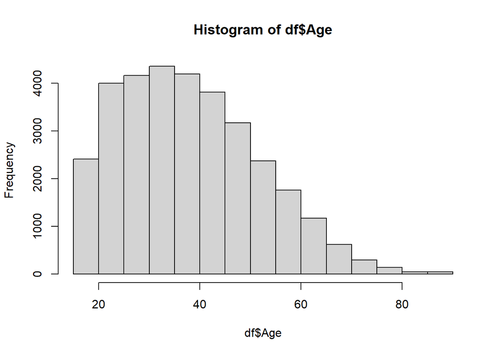

```r
hist(df$Age)
```

This data is skewed slightly right, 75% of adults in the dataset are younger than 48yrs old 50% of adults in data set lie between 28yrs old and 48yrs old age data has a range of 73 years

```r
cat("Types or Work Class")
```

```
## Types or Work Class
```

```r
str(df$Work_Class)
```

```
##  chr [1:32560] " Self-emp-not-inc" " Private" " Private" " Private" ...
```

```r
summary(df$Work_Class)
```

```
##    Length     Class      Mode
##     32560 character character
```

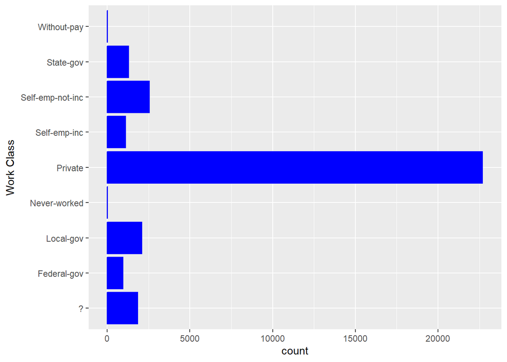

```r
ggplot(data = df) +
  geom_bar(mapping = aes(x = df$Work_Class), col = "blue", fill = "blue")+
  coord_flip() +
  labs(x = "Work Class")
```

```r
# Never-worked: 7
# Without-pay: 14
# Might be able to leave those 21 datapoints out
# Most people work for private corporations, followed by self employed (not incorporated), then
# local government, then unknown, then state government, then self employed (incorporated), then
# federal gov, and lastly by without pay and never worked
#

cat("Race")
```

```
## Race
```

```r
summary(df$Race)
```

```
##    Length     Class      Mode
##     32560 character character
```

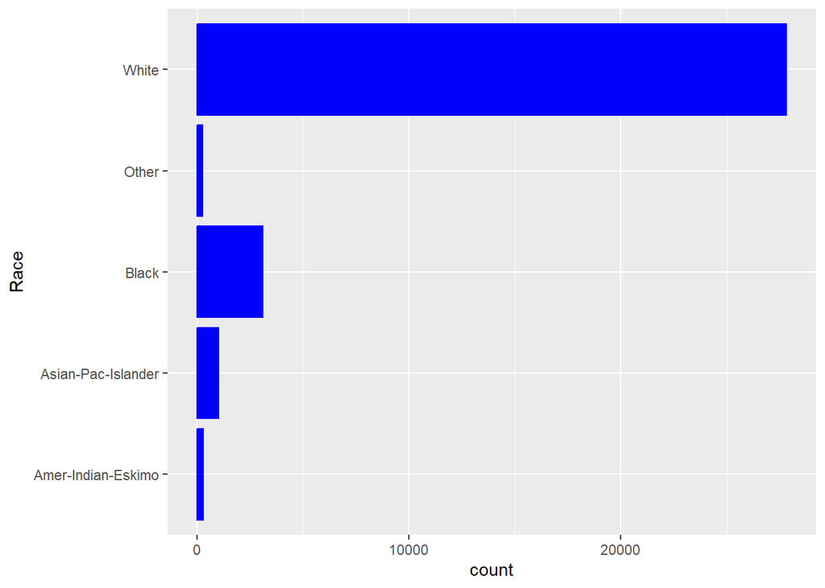

```r
ggplot(data = df) +
  geom_bar(mapping = aes(x = df$Race), col = "blue", fill = "blue") +
  coord_flip() +
  labs(x = "Race")
```

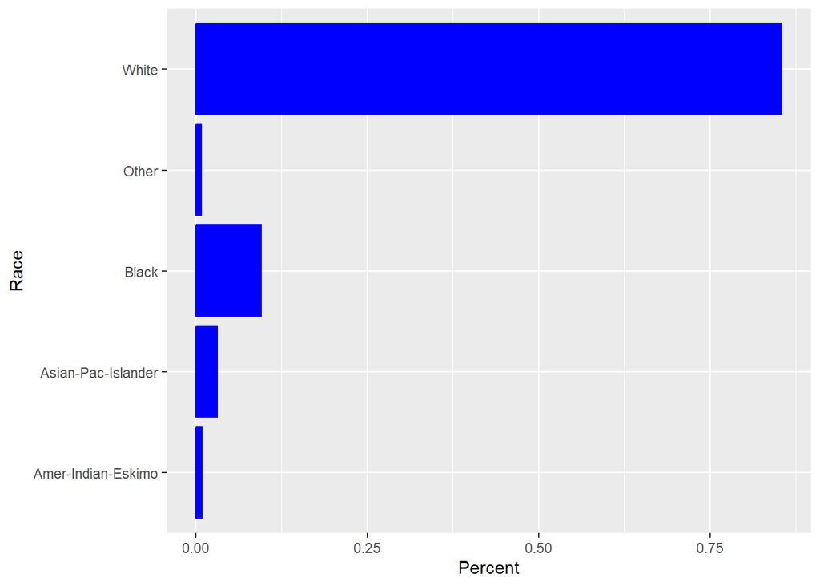

```r
ggplot(df, aes(x = df$Race)) +
  geom_bar(aes(y = (..count..)/sum(..count..)), col = "blue", fill = "blue") +
  coord_flip() +
  labs(x = "Race", y = "Percent")
```

```r
cat("# White: ~85.43%")
```

```
## # White: ~85.43%
```

```r
27816/32561
```

```
## [1] 0.8542735
```

```r
cat("# Black: ~9.6% ")
```

```
## # Black: ~9.6%
```

```r
3124/32561
```

```
## [1] 0.095943
```

```r
cat("# American-Indian-Eskimo: ~0.96%")
```

```
## # American-Indian-Eskimo: ~0.96%
```

```r
311/32561
```

```
## [1] 0.009551304
```

```r
cat("# Asian-Pacific-Island: ~3.2%")
```

```
## # Asian-Pacific-Island: ~3.2%
```

```r
1039/32561
```

```
## [1] 0.03190934
```

```r
cat("# Other: ~0.8%")
```

```
## # Other: ~0.8%
```

```r
271/32561
```

```
## [1] 0.00832284
```

```r
# Later generator: https://www.tablesgenerator.com/latex_tables
```

```r
cat("Sex")
```

```
## Sex
```

```r
summary(df$Sex)
```

```
##    Length     Class      Mode
##     32560 character character
```

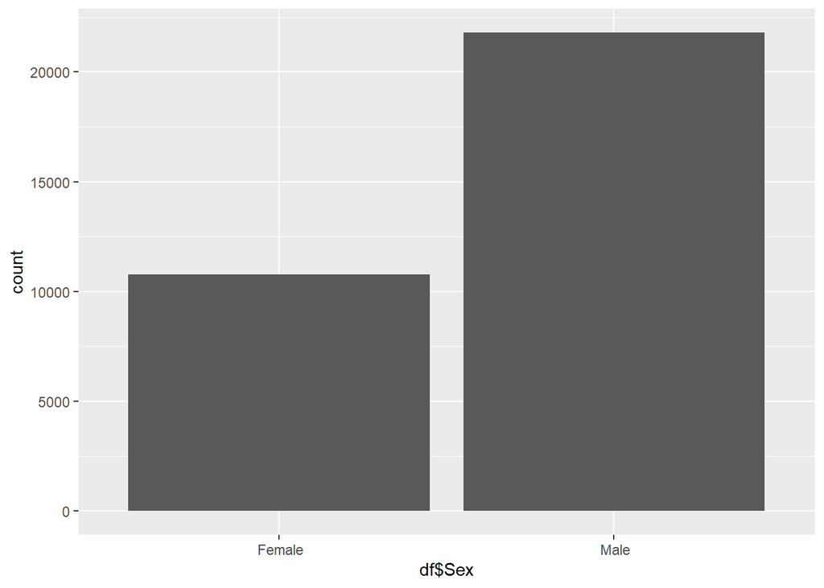

```r
ggplot(data = df) +
  geom_bar(mapping = aes(x = df$Sex))
```

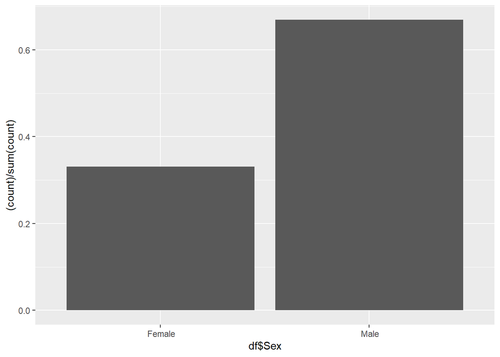

```r
ggplot(df, aes(x = df$Sex)) +
  geom_bar(aes(y = (..count..)/sum(..count..)))
```

```r
#female: ~33.1%
10771/32561
```

```
## [1] 0.3307945
```

```r
#male: ~66.9%
21790/32561
```

```
## [1] 0.6692055
```

The data is disproportionately male. According to the Bureau of Labor Statistics, the workforce is 47% female and 53% male.

```r
## Hours
summary(df$Hours_Per_Week)
```

```
##    Min. 1st Qu.  Median    Mean 3rd Qu.    Max.
##    1.00   40.00   40.00   40.44   45.00   99.00
```

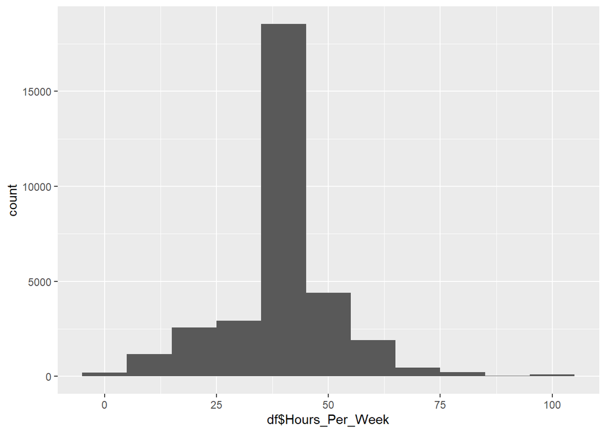

```r
ggplot() +
  geom_histogram(mapping = aes(x = df$Hours_Per_Week), data = df, stat = "bin",
                 binwidth = 10, bins = 6
  )
```

Worker’s Native Country information:

```r
summary(df$Native_Country)
```

```
##    Length     Class      Mode
##     32560 character character
```

```r
country_count <- data.frame(Name = df$Native_Country)
summary(country_count)
```

```
##      Name
##  Length:32560
##  Class :character
##  Mode  :character
```

```r
cat("Top three countries by frequency:")
```

```
## Top three countries by frequency:
```

```r
#   USA     :      29170 (~89.6%)
#   Mexico  :        643 (`2.00%)
#   Unknown :        582 (~1.8%)
#   Other   :       2165 (~6.65%)

cat("Summary of data USING DESCRIB(), HEAD(), SUMMARY(), AND STR()")
```

```
## Summary of data USING DESCRIB(), HEAD(), SUMMARY(), AND STR()
```

```r
head(df)
```

```
##   Age        Work_Class Sampling_Weight Highest_Education Education_Num
## 1  50  Self-emp-not-inc           83311         Bachelors            13
## 2  38           Private          215646           HS-grad             9
## 3  53           Private          234721              11th             7
## 4  28           Private          338409         Bachelors            13
## 5  37           Private          284582           Masters            14
## 6  49           Private          160187               9th             5
##           Martial_Status         Occupation   Relationship   Race     Sex
## 1     Married-civ-spouse    Exec-managerial        Husband  White    Male
## 2               Divorced  Handlers-cleaners  Not-in-family  White    Male
## 3     Married-civ-spouse  Handlers-cleaners        Husband  Black    Male
## 4     Married-civ-spouse     Prof-specialty           Wife  Black  Female
## 5     Married-civ-spouse    Exec-managerial           Wife  White  Female
## 6  Married-spouse-absent      Other-service  Not-in-family  Black  Female
##   Cap_Gain Cap_Loss Hours_Per_Week Native_Country Income
## 1        0        0             13  United-States  <=50K
## 2        0        0             40  United-States  <=50K
## 3        0        0             40  United-States  <=50K
## 4        0        0             40           Cuba  <=50K
## 5        0        0             40  United-States  <=50K
## 6        0        0             16        Jamaica  <=50K
```

```r
str(df)
```

```
## 'data.frame':    32560 obs. of  15 variables:
##  $ Age              : int  50 38 53 28 37 49 52 31 42 37 ...
##  $ Work_Class       : chr  " Self-emp-not-inc" " Private" " Private" " Private" ...
##  $ Sampling_Weight  : int  83311 215646 234721 338409 284582 160187 209642 45781 159449 280464 ...
##  $ Highest_Education: chr  " Bachelors" " HS-grad" " 11th" " Bachelors" ...
##  $ Education_Num    : int  13 9 7 13 14 5 9 14 13 10 ...
##  $ Martial_Status   : chr  " Married-civ-spouse" " Divorced" " Married-civ-spouse" " Married-civ-spouse" ...
##  $ Occupation       : chr  " Exec-managerial" " Handlers-cleaners" " Handlers-cleaners" " Prof-specialty" ...
##  $ Relationship     : chr  " Husband" " Not-in-family" " Husband" " Wife" ...
##  $ Race             : chr  " White" " White" " Black" " Black" ...
##  $ Sex              : chr  " Male" " Male" " Male" " Female" ...
##  $ Cap_Gain         : int  0 0 0 0 0 0 0 14084 5178 0 ...
##  $ Cap_Loss         : int  0 0 0 0 0 0 0 0 0 0 ...
##  $ Hours_Per_Week   : int  13 40 40 40 40 16 45 50 40 80 ...
##  $ Native_Country   : chr  " United-States" " United-States" " United-States" " Cuba" ...
##  $ Income           : chr  " <=50K" " <=50K" " <=50K" " <=50K" ...
```

```r
summary(df)
```

```
##       Age         Work_Class        Sampling_Weight   Highest_Education
##  Min.   :17.00   Length:32560       Min.   :  12285   Length:32560
##  1st Qu.:28.00   Class :character   1st Qu.: 117832   Class :character
##  Median :37.00   Mode  :character   Median : 178363   Mode  :character
##  Mean   :38.58                      Mean   : 189782
##  3rd Qu.:48.00                      3rd Qu.: 237055
##  Max.   :90.00                      Max.   :1484705
##  Education_Num   Martial_Status      Occupation        Relationship
##  Min.   : 1.00   Length:32560       Length:32560       Length:32560
##  1st Qu.: 9.00   Class :character   Class :character   Class :character
##  Median :10.00   Mode  :character   Mode  :character   Mode  :character
##  Mean   :10.08
##  3rd Qu.:12.00
##  Max.   :16.00
##      Race               Sex               Cap_Gain        Cap_Loss
##  Length:32560       Length:32560       Min.   :    0   Min.   :   0.00
##  Class :character   Class :character   1st Qu.:    0   1st Qu.:   0.00
##  Mode  :character   Mode  :character   Median :    0   Median :   0.00
##                                        Mean   : 1078   Mean   :  87.31
##                                        3rd Qu.:    0   3rd Qu.:   0.00
##                                        Max.   :99999   Max.   :4356.00
##  Hours_Per_Week  Native_Country        Income
##  Min.   : 1.00   Length:32560       Length:32560
##  1st Qu.:40.00   Class :character   Class :character
##  Median :40.00   Mode  :character   Mode  :character
##  Mean   :40.44
##  3rd Qu.:45.00
##  Max.   :99.00
```

```r
#describe(df)

cat("#It shows that 24.1% of adults make more than 50K USD")
```

```
## #It shows that 24.1% of adults make more than 50K USD
```

```r
cat("Most people (75%) make less than or equal to 50K USD annually")
```

```
## Most people (75%) make less than or equal to 50K USD annually
```

```r
cat("Let's look at the relationships between the variables")
```

```
## Let's look at the relationships between the variables
```

```r
cat(" Totals individuals making more than 50K")
```

```
##  Totals individuals making more than 50K
```

```r
sum(df$Income==" >50K") #7841
```

```
## [1] 7841
```

```r
cat("Total White:")
```

```
## Total White:
```

```r
sum(df$Race==" White") #27816
```

```
## [1] 27815
```

```r
cat("Total White making more than 50K")
```

```
## Total White making more than 50K
```

```r
sum(df$Income==" >50K" & df$Race==" White") #7117
```

```
## [1] 7117
```

```r
cat("Total Non-White making more than 50K")
```

```
## Total Non-White making more than 50K
```

```r
sum(df$Income==" >50K" & df$Race!=" White") #724
```

```
## [1] 724
```

```r
cat("Total White making less than 50K")
```

```
## Total White making less than 50K
```

```r
sum(df$Income==" <=50K" & df$Race==" White") #20699
```

```
## [1] 20698
```

```r
cat ("Percent of adults making more than 50K and are White:")
```

```
## Percent of adults making more than 50K and are White:
```

```r
sum(df$Income==" >50K" & df$Race==" White")/sum(df$Income==" >50K") *100
```

```
## [1] 90.76648
```

```r
cat ("Percent of White adults making more than 50K:")
```

```
## Percent of White adults making more than 50K:
```

```r
sum(df$Income==" >50K" & df$Race==" White")/sum(df$Race==" White") *100
```

```
## [1] 25.58691
```

White adults make up 90.77% of adults making more than 50K USD Non-white adults make up 9.23% of adults making more than 50K USD 25.6% of White adults make more than 50K USD

We can repeat the same analysis for Black population:

```r
cat("Race -- Black")
```

```
## Race -- Black
```

```r
cat("Total black individuals")
```

```
## Total black individuals
```

```r
sum(df$Race==" Black") #3124
```

```
## [1] 3124
```

```r
cat("Totals individuals making more than 50K")
```

```
## Totals individuals making more than 50K
```

```r
sum(df$Income==" >50K" & df$Race==" Black") #387
```

```
## [1] 387
```

```r
cat("Total Non-Black making more than 50K")
```

```
## Total Non-Black making more than 50K
```

```r
sum(df$Income==" >50K" & df$Race!=" Black") #7454
```

```
## [1] 7454
```

```r
cat("Total Black making less than 50K")
```

```
## Total Black making less than 50K
```

```r
sum(df$Income==" <=50K" & df$Race==" Black") #2737
```

```
## [1] 2737
```

```r
cat ("percent of adults making more than 50K and are Black:")
```

```
## percent of adults making more than 50K and are Black:
```

```r
sum(df$Income==" >50K" & df$Race==" Black")/sum(df$Income==" >50K") *100
```

```
## [1] 4.935595
```

```r
cat ("percent of blacks adults making more than 50K:")
```

```
## percent of blacks adults making more than 50K:
```

```r
sum(df$Income==" >50K" & df$Race==" Black")/sum(df$Race==" Black") *100
```

```
## [1] 12.38796
```

Black adults make up 4.935% of adults making more than 50K USD; 12.38% of Black adults make more than 50K USD

We repeat the same analysis for American Indian:

```r
cat("Total Race -- Amer-Indian-Eskimo")
```

```
## Total Race -- Amer-Indian-Eskimo
```

```r
sum(df$Race==" Amer-Indian-Eskimo") #311
```

```
## [1] 311
```

```r
cat("Amer-Indian-Eskimo making more than 50K: ")
```

```
## Amer-Indian-Eskimo making more than 50K:
```

```r
sum(df$Income==" >50K" & df$Race==" Amer-Indian-Eskimo") #36
```

```
## [1] 36
```

```r
cat("Total non-Amer-Indian-Eskimo making more than 50K: ")
```

```
## Total non-Amer-Indian-Eskimo making more than 50K:
```

```r
sum(df$Income==" >50K" & df$Race!=" Amer-Indian-Eskimo") #7805
```

```
## [1] 7805
```

```r
cat("Amer-Indian-Eskimo making less than 50K: ")
```

```
## Amer-Indian-Eskimo making less than 50K:
```

```r
sum(df$Income==" <=50K" & df$Race==" Amer-Indian-Eskimo") #275
```

```
## [1] 275
```

```r
cat ("percent of adults making more than 50K and are Amer-Indian-Eskimo:")
```

```
## percent of adults making more than 50K and are Amer-Indian-Eskimo:
```

```r
sum(df$Income==" >50K" & df$Race==" Amer-Indian-Eskimo")/sum(df$Income==" >50K") *100
```

```
## [1] 0.4591251
```

```r
cat ("percent of Amer-Indian-Eskimo adults making more than 50K:")
```

```
## percent of Amer-Indian-Eskimo adults making more than 50K:
```

```r
sum(df$Income==" >50K" & df$Race==" Amer-Indian-Eskimo")/sum(df$Race==" Amer-Indian-Eskimo") *100
```

```
## [1] 11.57556
```

Amer-Indian-Eskimo adults make up 0.5% of adults making more than 50K USD 11.6% of Amer-Indian-Eskimo adults make more than 50K USD

We can repeat this analysis for Asian-Pac-Islander

```r
cat("Race -- Asian-Pac-Islander")
```

```
## Race -- Asian-Pac-Islander
```

```r
cat("Total Race -- Asian-Pac-Islander")
```

```
## Total Race -- Asian-Pac-Islander
```

```r
sum(df$Race==" Asian-Pac-Islander") #1039
```

```
## [1] 1039
```

```r
cat("Asian-Pac-Islander making more than 50K: ")
```

```
## Asian-Pac-Islander making more than 50K:
```

```r
sum(df$Income==" >50K" & df$Race==" Asian-Pac-Islander") #276
```

```
## [1] 276
```

```r
cat("Total non-Asian-Pac-Islander making more than 50K: ")
```

```
## Total non-Asian-Pac-Islander making more than 50K:
```

```r
sum(df$Income==" >50K" & df$Race!=" Asian-Pac-Islander") #7565
```

```
## [1] 7565
```

```r
cat("Asian-Pac-Islander making less than 50K: ")
```

```
## Asian-Pac-Islander making less than 50K:
```

```r
sum(df$Income==" <=50K" & df$Race==" Asian-Pac-Islander") #763
```

```
## [1] 763
```

```r
cat ("percent of adults making more than 50K and are Asian-Pac-Islander:")
```

```
## percent of adults making more than 50K and are Asian-Pac-Islander:
```

```r
sum(df$Income==" >50K" & df$Race==" Asian-Pac-Islander")/sum(df$Income==" >50K") *100
```

```
## [1] 3.519959
```

```r
cat ("percent of Asian-Pac-Islander adults making more than 50K:")
```

```
## percent of Asian-Pac-Islander adults making more than 50K:
```

```r
sum(df$Income==" >50K" & df$Race==" Asian-Pac-Islander")/sum(df$Race==" Asian-Pac-Islander") *100
```

```
## [1] 26.564
```

Asian-Pac-Islander adults make up 3.5% of adults making more than 50K USD 26.56% of Asian-Pac-Islander adults make more than 50K USD

We can repeat this for all other race:

```r
cat("Race -- Other")
```

```
## Race -- Other
```

```r
cat("Total Race -- Other")
```

```
## Total Race -- Other
```

```r
sum(df$Race==" Other") #271
```

```
## [1] 271
```

```r
cat("Other-race making more than 50K: ")
```

```
## Other-race making more than 50K:
```

```r
sum(df$Income==" >50K" & df$Race==" Other") #25
```

```
## [1] 25
```

```r
cat("Non-Other-race making more than 50K: ")
```

```
## Non-Other-race making more than 50K:
```

```r
sum(df$Income==" >50K" & df$Race!=" Other") #7816
```

```
## [1] 7816
```

```r
cat("Other-race making less than 50K: ")
```

```
## Other-race making less than 50K:
```

```r
sum(df$Income==" <=50K" & df$Race==" Other") #246
```

```
## [1] 246
```

```r
cat ("percent of adults making more than 50K and are Other-race:")
```

```
## percent of adults making more than 50K and are Other-race:
```

```r
sum(df$Income==" >50K" & df$Race==" Other")/sum(df$Income==" >50K") *100
```

```
## [1] 0.3188369
```

```r
cat ("percent of Other-race adults making more than 50K:")
```

```
## percent of Other-race adults making more than 50K:
```

```r
sum(df$Income==" >50K" & df$Race==" Other")/sum(df$Race==" Other") *100
```

```
## [1] 9.225092
```

Now we can also compare other variables like Gender

```r
#Sex -- Male
sum(df$Sex==" Male") #21790
```

```
## [1] 21789
```

```r
sum(df$Sex==" Male" & df$Income==" >50K") #6662
```

```
## [1] 6662
```

```r
sum(df$Sex==" Male" & df$Income!=" >50K") #15128
```

```
## [1] 15127
```

```r
cat("30.6% of Male adults make more than 50K USD annually; 85% of adults making more than 50K USD annually are Male")
```

```
## 30.6% of Male adults make more than 50K USD annually; 85% of adults making more than 50K USD annually are Male
```

```r
#Sex == Female
sum(df$Sex==" Female") #10771
```

```
## [1] 10771
```

```r
sum(df$Sex==" Female" & df$Income==" >50K") #1179
```

```
## [1] 1179
```

```r
sum(df$Sex==" Female" & df$Income!=" >50K") #9592
```

```
## [1] 9592
```

```r
cat("11% of Female adults make more than 50K USD annually; 15% of adults making more than 50K USD annually are Female")
```

```
## 11% of Female adults make more than 50K USD annually; 15% of adults making more than 50K USD annually are Female
```

```r
#Sex -- Male AND Race -- White AND
sum(df$Sex==" Female" & df$Race==" White" & df$Income ==" >50K") #1028
```

```
## [1] 1028
```

```r
sum(df$Sex==" Male" & df$Race==" White" & df$Income ==" >50K") #6089
```

```
## [1] 6089
```

```r
cat("13.11% of adults making more than 50K USD annually are White Females; 77.66% of adults making more than 50K USD annually are White Males; 85.6% of White adults making more than 50K USD annually are Males")
```

```
## 13.11% of adults making more than 50K USD annually are White Females; 77.66% of adults making more than 50K USD annually are White Males; 85.6% of White adults making more than 50K USD annually are Males
```

```r
sum(df$Sex==" Female" & df$Race==" Black" & df$Income ==" >50K") #90
```

```
## [1] 90
```

```r
sum(df$Sex==" Male" & df$Race==" Black" & df$Income ==" >50K") #297
```

```
## [1] 297
```

```r
cat ("1.15% of adults making more than 50K USD annually are Black Females; 3.79% of adults making more than 50K USD annually are Black Males; 76.75% of Black adults making more than 50K USD annually are Males")
```

```
## 1.15% of adults making more than 50K USD annually are Black Females; 3.79% of adults making more than 50K USD annually are Black Males; 76.75% of Black adults making more than 50K USD annually are Males
```

```r
sum(df$Sex==" Female" & df$Race==" Asian-Pac-Islander" & df$Income ==" >50K") #43
```

```
## [1] 43
```

```r
sum(df$Sex==" Male" & df$Race==" Asian-Pac-Islander" & df$Income ==" >50K") #233
```

```
## [1] 233
```

```r
cat("0.5% of adults making more than 50K USD annually are Asian/Pacific Islander Females; 2.97% of adults making more than 50K USD annually are Asian/Pacific Islander Males; 84.42% of Asian adults making more than 50K USD annually are Male")
```

```
## 0.5% of adults making more than 50K USD annually are Asian/Pacific Islander Females; 2.97% of adults making more than 50K USD annually are Asian/Pacific Islander Males; 84.42% of Asian adults making more than 50K USD annually are Male
```